# Project Business Statistics: E-news Express

### Observation:

- The new landing page recorded higher conversion count(Whether the user gets converted to a subscriber of the news portal or not) than the old landing page.

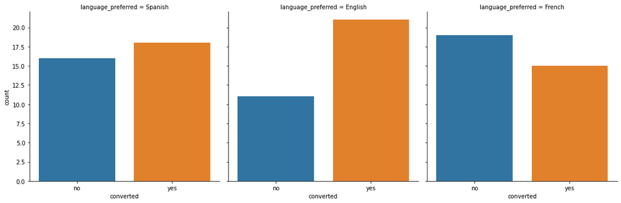

```python
# Analyse conversion based on language preferred
sns.catplot(data = ds, x = 'converted', col = 'language_preferred', kind = 'count');
```

### Observation:

- Spanish and English languages recorded a higher amount of converts to those that didn't convert as opposed to French language, where more users didnt convert.

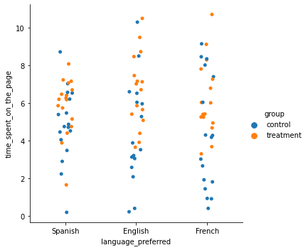

```python
sns.catplot(data = ds, x = 'language_preferred', hue='group',y='time_spent_on_the_page');
```

### Observation:

- Those in treament group send longer times on the new landing page.

## 1. Do the users spend more time on the new landing page than the existing landing page?

### Perform Visual Analysis

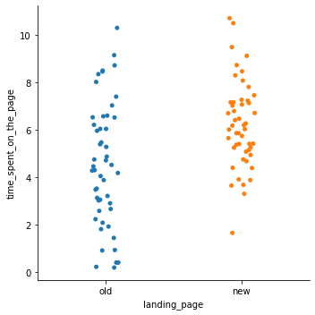

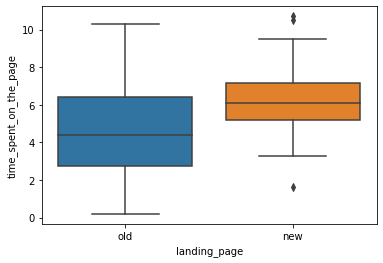

```
The mean time spent on the old landing page is  4.53 minutes.
The mean time spent on the new landing page is  6.22 minutes.
```

```python
sns.catplot(data = ds, x = 'landing_page',y='time_spent_on_the_page')
plt.show()
sns.boxplot(data = ds, x = 'landing_page', y = 'time_spent_on_the_page')
plt.show()
print('The mean time spent on the old landing page is ',str(round(ds_old['time_spent_on_the_page'].mean(),2)),'minutes.')
print('The mean time spent on the new landing page is ',str(round(ds_new['time_spent_on_the_page'].mean(),2)),'minutes.')
```

### Step 1: Define the null and alternate hypotheses

let's define the null and alternate hypothesis

- H0: The mean time spent on the new landing page is equal to the mean time spent on the old landing page.
- Ha: The mean time spent on the new landing page is greater than the mean time spent on the old landing page.

Hence we test the null

- H0:μ1=μ2

against the alternate hypothesis

- Ha:μ1>μ2

from this we can conclude that this hypothesis is a one-tailed test with 2 sample means. so we will be using a two sample mean test.

### Step 2: Select Appropriate test

Let's analyse all our data to know the best type of test to use for our hypothesis testing.

- Continuous data - Yes, the time spent on the pages are measured on a continuous scale.
- Normally distributed populations -The sample size of 50 is greater than 30, hence Central Limit Theorem is applicable .
- Independent populations -The samples are taken from two different groups(control and treatment groups), hence we can assume that the populations are independent.
- Unequal population standard deviations -The sample standard deviations are different, we can assume that the population standard deviations are different.
- Random sampling from the population - we are informed that the samples collected are randomly selected.

From the above confirmations, the most appropriate test to use is the Two Independent Sample T-test for Equality of Means - Unequal Std Dev.

### Step 3: Decide the significance level

- The given significance level(𝛂) is 5% (0.05)

### Step 4: Collect and prepare data

```python
print('μ1 = ',str(round(ds_old['time_spent_on_the_page'].mean(),2)),'minutes.')
print('μ2 = ',str(round(ds_new['time_spent_on_the_page'].mean(),2)),'minutes.')
print('std1 = ',str(round(ds_old['time_spent_on_the_page'].std(),2)),'minutes.')
print('std2 = ',str(round(ds_new['time_spent_on_the_page'].std(),2)),'minutes.')
```

```
μ1 =  4.53 minutes.
μ2 =  6.22 minutes.
std1 =  2.58 minutes.
std2 =  1.82 minutes.
```

### Step 5: Calculate the p-value

```python
# import the required function to compute the test statistic and p-value.
from scipy.stats import ttest_ind
```

```python
# For this test we will be using the p-value
test_stat, p_value = ttest_ind(ds_new['time_spent_on_the_page'],ds_old['time_spent_on_the_page'].dropna(),equal_var = False, alternative = 'greater')
print('The p-value is ', p_value)
```

```
The p-value is  0.0001392381225166549
```

### Step 6: Compare the p-value with $\alpha$

```python
# print the conclusion based on p-value
if p_value < 0.05:
    print(f'Since the p-value {p_value} is less than the level of significance, we reject the null hypothesis.')
else:
    print(f'Since the p-value {p_value} is greater than the level of significance, we fail to reject the null hypothesis.')
```

```
Since the p-value 0.0001392381225166549 is less than the level of significance, we reject the null hypothesis.
```

### Step 7: Draw inference

- Using the significance level of 0.05; our p_value is less than the significance level, hence we reject the null hypothesis.
- We have enough evidence to prove that the mean time spent on the new landing page is greater than the mean time spent on the old landing page.

**A similar approach can be followed to answer the other questions.**

## 2. Is the conversion rate (the proportion of users who visit the landing page and get converted) for the new page greater than the conversion rate for the old page?

### Perform Visual Analysis

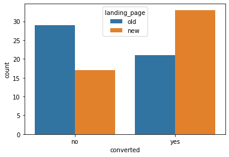

```python
sns.countplot(x='converted', data=ds, hue='landing_page');
```

### Observation:

- The new landing page recorded higher number numbers of converted users.

### Step 1: Define the null and alternate hypotheses

- Let p1 = conversion rate for new landing page.
- let p2 = conversion rate for old landing page.

let's define the null and alternate hypothesis

- H0: The conversion rate for the new landing page is equal to the conversion rate for the old landing page.
- Ha: The conversion rate for the new landing page is greater than the conversion rate of the old landing page. Hence we test the null
- H0:p1=p2

against the alternate hypothesis

- Ha:p1>p2 from this we can conclude that this hypothesis is a one-tailed test .

### Step 2: Select Appropriate test

- The above hypotheses are concerned with proportions. We shall use a Proportions Z test to analyse the hypotheses and draw a conclusion for this problem.

### Step 3: Decide the significance level

- The given significance level(𝛂) is 5% (0.05)

### Step 4: Collect and prepare data

```python
# calculate the number of converts from new page
new_converted = ds[ds['converted']=='yes'].landing_page.value_counts()['new']
#  calculate the number of converts from old page
old_converted = ds[ds['converted']=='yes'].landing_page.value_counts()['old']

print('The number of new page converts is {0}'.format(new_converted))
print('The number of old page converts is {0} '.format(old_converted))
```

```
The number of new page converts is 33
The number of old page converts is 21
```

```python
p1= round(new_converted/50,2)
p2= round(old_converted/50,2)
print(f'p1 and p2 are {p1} and {p2} respectively.')
```

```
p1 and p2 are 0.66 and 0.42 respectively.
```

### Observation:

from the above, the p1 seems to be greater than p2

### Step 5: Calculate the p-value

```python
# import the required function
from statsmodels.stats.proportion import proportions_ztest
# calculate the p_value
stat, p_value = proportions_ztest([new_converted, old_converted], [50, 50], alternative = 'larger')
# print the p-value
print('The p-value is '+ str(p_value))
```

```
The p-value is 0.008026308204056278
```

### Step 6: Compare the p-value with $\alpha$

```python
# print the conclusion based on p-value
if p_value < 0.05:
    print(f'Since the p-value {p_value} is less than the level of significance, we reject the null hypothesis.')
else:
    print(f'Since the p-value {p_value} is greater than the level of significance, we fail to reject the null hypothesis.')
```

```
Since the p-value 0.008026308204056278 is less than the level of significance, we reject the null hypothesis.
```

### Step 7: Draw inference

- Using the significance level of 0.05; our p_value is less than the significance level, hence we reject the null hypothesis.
- We have enough evidence to prove that the conversion rate of the new landing page is greater than the conversion rate of the old landing page.

## 3. Is the conversion and preferred language are independent or related?

### Perform Visual Analysis

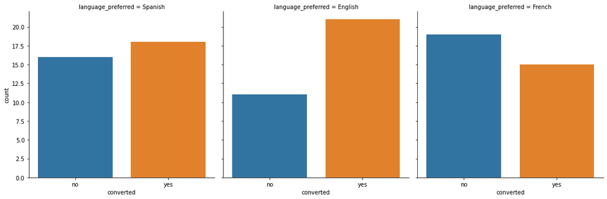

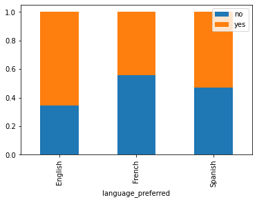

```python
sns.catplot(data = ds, x = 'converted', col = 'language_preferred', kind = 'count')
plt.show()
pd.crosstab(ds['language_preferred'],ds['converted'],normalize='index').plot(kind='bar',stacked =True)
plt.legend()
plt.show()
```

### Observation:

- The abve graph doesn't seem to show any serious relationship between the conversion and preferred language.

### Define the null and alternate hypotheses

let's define the null and alternate hypothesis

- H0: conversion and language preferred are independent

against

- Ha: conversion and language preferred are not independent(they are related)

### Select Appropriate test

The formulated hypotheses can be tested using a Chi-square test of independence of attributes (Test to check if 2 categorical variables are related or not).

Let's test whether the assumptions are satisfied or not

- Categorical variables - Yes
- Expected value of the number of sample observations in each level of the variable is at least 5 - Yes, the number of observations in each level is greater than 5.
- Random sampling from the population - Yes, we are informed that the collected sample is a simple random sample.

#### Decide the significance level

- The given significance level(𝛂) is 5% (0.05)

### Collect and prepare data

```python
# create a contingency table
cont_table = pd.crosstab(ds['converted'], ds['language_preferred'])
cont_table
```

| language_preferred converted | English | French | Spanish |
| --- | --- | --- | --- |
| no | 11 | 19 | 16 |
| yes | 21 | 15 | 18 |

### Calculate the p-value

```python
# impport the required function
from scipy.stats import chi2_contingency
# Calculate the p_value
chi2, p_value, dof, expected_frequency = chi2_contingency(cont_table)
# print the p-value
print('The p-value is', p_value)
```

```
The p-value is 0.21298887487543447
```

#### Compare the p-value with $\alpha$

```python
# print the conclusion based on p-value
if p_value < 0.05:
    print(f'Since the p-value {p_value} is less than the level of significance, we reject the null hypothesis.')
else:
    print(f'Since the p-value {p_value} is greater than the level of significance, we fail to reject the null hypothesis.')
```

```
Since the p-value 0.21298887487543447 is greater than the level of significance, we fail to reject the null hypothesis.
```

## 4. Is the time spent on the new page same for the different language users?

### Perform Visual Analysis

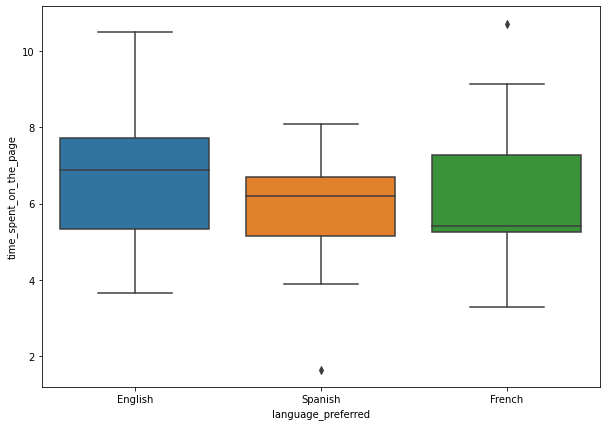

```python
plt.figure(figsize=(10,7))
sns.boxplot( data = ds_new,x='language_preferred', y='time_spent_on_the_page')
plt.show()
```